# Survey Results

### 2.2 Preferences and Topic Importantance

```r
data_loc_long <- data |>
  pivot_longer(
    cols = c(paste0("ALCL", 1:10), paste0("ALCL", 1:10, "_imp")),
    names_to = "Label",
    values_to = "Response"
  ) |>
  mutate(
    Type = if_else(
      str_detect(Label, "_imp"),
      "Importance",
      "Preference"
    ),
    Label = str_remove(Label, "_imp")
  ) |>
  pivot_wider(names_from = Type, values_from = Response) |>
  mutate(
    Importance = if_else(Importance == 1, "Important", "Not Important") |>
      fct_inorder()
  ) |>
  left_join(loc_domains_questions, by = "Label") |>
  mutate(Label = Label |> fct_inorder())
data_loc_long_fractions <- data_loc_long |>
  count(Label, Preference, Importance) |>
  mutate(Fraction = n / sum(n), .by = Label)
```

The answering categories for the local preference questions were $-2,-1,0,+1,+2$ as in the original Voting Advice Application.

Additionally, each respondent was asked to select the three most important local topics for them. The following table shows the fraction of respondents that selected each topic as one of their three most important topics.

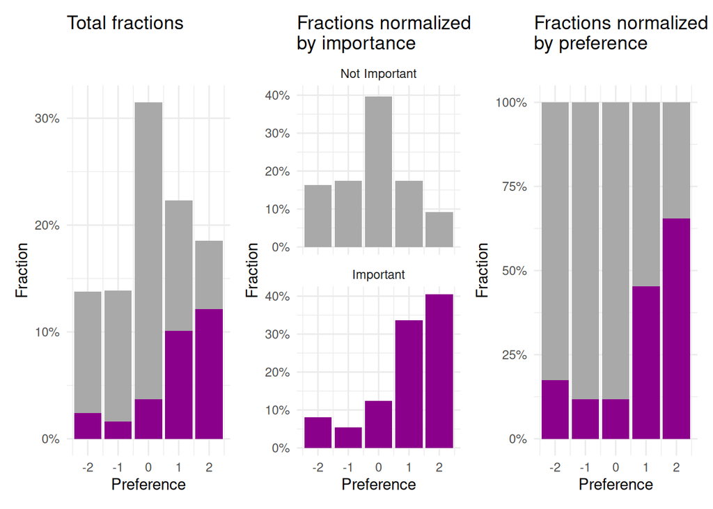

Figure 6: Distributions of local preferences and its relation to whether the topic was also marked as important.

```r
pi1 <- data_loc_long_fractions |>
  mutate(Fraction = Fraction / 10) |>
  ggplot(aes(x = Preference, y = Fraction, fill = Importance)) +
  geom_col() +
  scale_y_continuous(labels = percent_format(accuracy = 1)) +
  scale_fill_manual(
    values = c("Not Important" = "darkgray", "Important" = "darkmagenta")
  ) +
  labs(title = "Total fractions") +
  guides(fill = "none") +
  theme_minimal()

pi2 <- data_loc_long |>
  count(Preference, Importance) |>
  mutate(Fraction = n / sum(n), .by = Importance) |>
  ggplot(aes(x = Preference, y = Fraction, fill = Importance)) +
  geom_col() +
  scale_y_continuous(labels = percent_format(accuracy = 1)) +
  scale_fill_manual(
    values = c("Not Important" = "darkgray", "Important" = "darkmagenta")
  ) +
  facet_wrap(~Importance, nrow = 2) +
  labs(title = "Fractions normalized\nby importance") +
  guides(fill = "none") +
  theme_minimal()

pi3 <- data_loc_long |>
  count(Preference, Importance) |>
  mutate(Fraction = n / sum(n), .by = Preference) |>
  ggplot(aes(x = Preference, y = Fraction, fill = Importance)) +
  geom_col() +
  scale_y_continuous(labels = percent_format(accuracy = 1)) +
  scale_fill_manual(
    values = c("Not Important" = "darkgray", "Important" = "darkmagenta")
  ) +
  labs(title = "Fractions normalized\nby preference") +
  guides(fill = "none") +
  theme_minimal()

pi1 + pi2 + pi3 + plot_layout(nrow = 1)
```

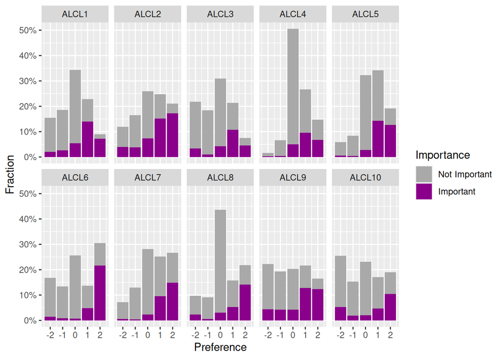

Figure 7: Preference distributions for the ten local topics. Questions in Table 3.

```r
data_loc_long_fractions |>
  ggplot(aes(x = Preference, y = Fraction, fill = Importance)) +
  geom_col() +
  scale_y_continuous(labels = percent_format(accuracy = 1)) +
  scale_x_continuous(breaks = -2:2) +
  scale_fill_manual(
    values = c("Important" = "darkmagenta", "Not Important" = "darkgray")
  ) +
  facet_wrap(~Label, nrow = 2)
```

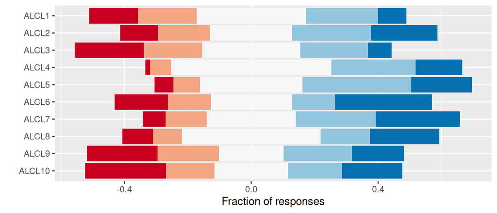

Figure 8: Preference distributions for the ten local topics in Likert plotting style. Questions in Table 3.

```r
data_loc_long_fractions |>
  summarise(Fraction = sum(Fraction), .by = c(Label, Preference)) |>
  ggplot(aes(
    y = Label |> fct_rev(),
    fill = Preference |> as.factor(),
    x = Fraction
  )) +
  geom_col(position = "likert") +
  scale_fill_brewer(type = "div", palette = "RdBu") +
  labs(x = "Fraction of responses", y = "") +
  guides(fill = "none")
```

```r
data_loc_long |>
  summarise(
    Question = first(Preference_q),
    Importance = mean(as.numeric(Importance) - 1),
    Mean = mean(Preference),
    SD = sd(Preference),
    .by = c(Label)
  ) |>
  arrange(desc(Importance)) |>
  gt() |>
  fmt_number(columns = everything(), decimals = 2) |>
  fmt_percent(columns = Importance, decimals = 1) |>
  data_color(
    columns = starts_with("Mean"),
    palette = "BuGn",
    method = "numeric",
    domain = c(-0.6, +0.6)
  ) |>
  data_color(
    columns = starts_with("SD"),
    palette = "OrRd",
    method = "numeric",
    domain = c(0.5, 1.5)
  ) |>
  data_color(
    columns = starts_with("Importance"),
    palette = "PuRd",
    method = "numeric",
    domain = c(0, 0.5)
  ) |>
  opt_interactive(use_pagination = FALSE) |>
  cols_width(
    Label ~ px(90),
    Question ~ px(420),
    Importance ~ px(120),
    Mean ~ px(80),
    SD ~ px(80)
  )
```

Table 6: Preference summary statistics for the ten local topics. (Interactive sorting by clicking on column headers.)

| Label | Question | Importance | Mean | SD |
| --- | --- | --- | --- | --- |
| ALCL2 | It is possible to save money in the public sector without affecting public welfare. | 0.474975466143278 | 0.264965652600589 | 1.28786815889413 |
| ALCL9 | Car traffic in Aarhus city center must be limited, for example through one-way directions, speed reductions and a zero-emission zone. | 0.379784102060844 | -0.0932286555446516 | 1.39749399544744 |
| ALCL1 | Municipal tax in Aarhus Municipality must be raised, and the money must be spent on better welfare. | 0.313052011776251 | -0.0873405299313052 | 1.17489567853415 |
| ALCL5 | Aarhus Municipality must prioritize that school pupils are mixed according to ethnicity and social background. | 0.307163886162905 | 0.52306182531894 | 1.0749003001718 |
| ALCL6 | The politicians must prevent the construction of mosques. | 0.294406280667321 | 0.276741903827282 | 1.44511873432849 |
| ALCL7 | More parking spaces must be established in Aarhus Municipality. | 0.275760549558391 | 0.510304219823356 | 1.21331909553717 |
| ALCL8 | The city council's temporary stop for the expansion of Aarhus Harbor must be made permanent. | 0.253189401373896 | 0.307163886162905 | 1.18969779707307 |
| ALCL10 | The municipality must continue with the plans for the new football stadium in Kongelunden, even if the costs rise again. | 0.243375858684985 | -0.113837095191364 | 1.4460823360889 |
| ALCL3 | More tasks in the public sector must be solved by private companies. | 0.239450441609421 | -0.25711481844946 | 1.22620211558193 |
| ALCL4 | Aarhus Municipality must make it cheaper to run a business. | 0.218842001962709 | 0.463199214916585 | 0.87722211276682 |

### 2.3 Principal Component Analysis on local preferences

Insights:

- The Principal Component Analysis (PCA) shows PC1 capturing more than 30% of the variance of the 10 local preference items, and PC2 captures 12%, and PC3 and PC4 still slightly more than the average 10%.
- PC1 has ALCL1 and ALCL9 strongly on the negative side and ALCL2-4 and ALCL6-7 on the positive side. (Note the sign of the PC loadings has no intrinsic positive of negative meaning). ALCL5 and ALCL8 are also on the negative side and ALCL10 loads very low on PC1. So, respondents with negative values in PC1 are in favour of raising taxes for welfare and on limiting car traffic, they also favour (mildly) mixing in schools and stopping the expansion of Aarhus Harbor, while they believe money can’t be saved in the public sector, these tasks should not given to private companies, running business need not be cheaper, construction of mosques need not be prevented, and no more parking space is needed. So, negative values of PC1 stand for a classical economically left and culturally liberal profile, and positive values for an culturally conservative/economically liberal profile. The question on the stadium is the only mostly unrelated topic on PC1.

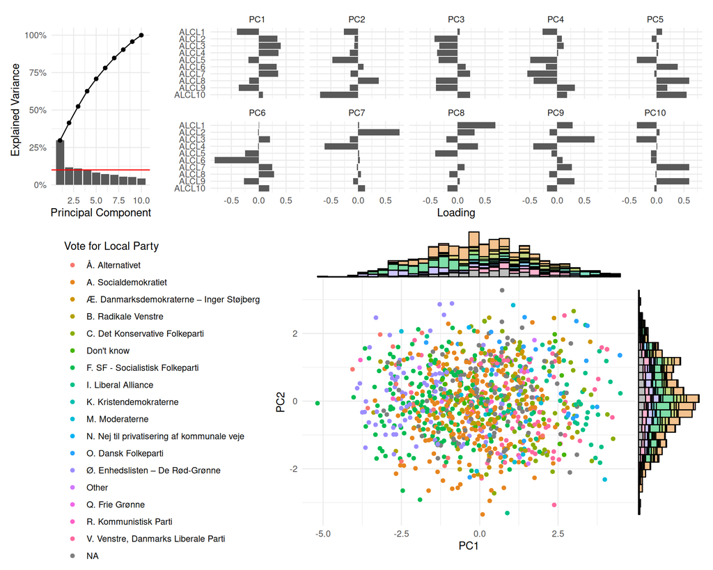

Figure 9: Principal Component Analysis on local preferences for the ten topics. Questions in Table 3.

```r
prcomp_pref_loc <- data |>
  select(paste0("ALCL", 1:10)) |>
  prcomp(scale. = TRUE)
prcomp_pref_loc$x <- prcomp_pref_loc$x |>
  as_tibble() |>
  bind_cols(data)

prcomp_plot(
  prcomp_pref_loc,
  VOTE_LOC_PRTY,
  "Vote for Local Party",
  plot_heights = c(1, 2)
)
```

### 2.4 Correlation

Mental models of the preference formation model are based on correlation matrices. To that end we group respondents by not preference related characteristics and calculate the correlation matrices of the ten local preference items for each group.

#### 2.4.1 Demographic groups

```r
data |>
  mutate(
    AGE_GROUP = case_when(
      AGE <= 27 ~ "Young (<=27)",
      AGE > 27 & AGE <= 39 ~ "Middle (28-39)",
      AGE > 39 & AGE <= 66 ~ "Middle (40-66)",
      AGE > 66 ~ "Old (>=66)"
    ),
    GENDER_binary = case_when(
      GENDER == "Male" ~ "Male",
      GENDER == "Female" ~ "Female",
      TRUE ~ "Female"
    )
  ) |>
  count(AGE_GROUP, GENDER_binary)
```

```
# A tibble: 8 × 3
  AGE_GROUP      GENDER_binary     n
  <chr>          <chr>         <int>
1 Middle (28-39) Female           89
2 Middle (28-39) Male             83
3 Middle (40-66) Female          199
4 Middle (40-66) Male            163
5 Old (>=66)     Female          109
6 Old (>=66)     Male            176
7 Young (<=27)   Female          138
8 Young (<=27)   Male             62
```

```
Correlation computed with
• Method: 'pearson'
• Missing treated using: 'pairwise.complete.obs'
```

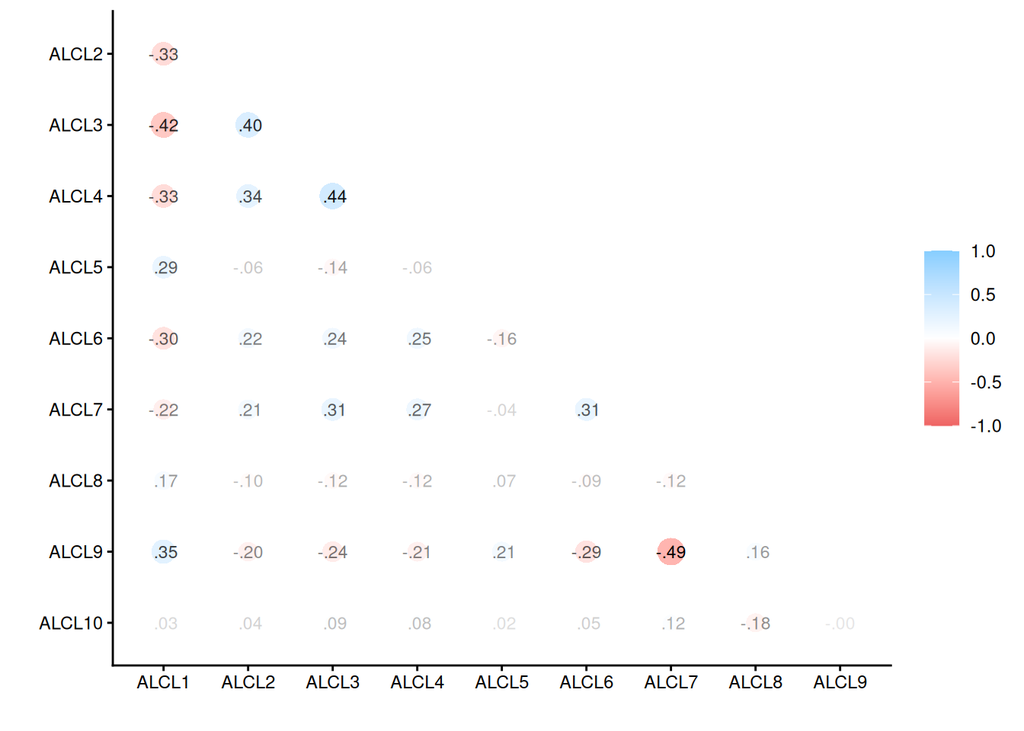

Figure 10: Correlation matrix of the ten local preference items.

```r
data |>
  select(paste0("ALCL", 1:10)) |>
  correlate() |>
  shave() |>
  rplot(print_cor = TRUE)
```

```
Correlation computed with
• Method: 'pearson'
• Missing treated using: 'pairwise.complete.obs'
```

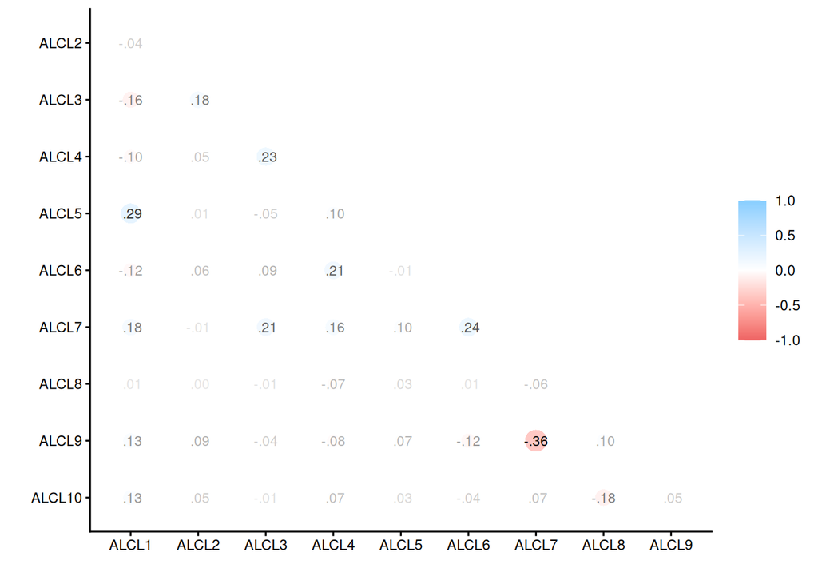

Figure 11: Correlation matrix of the ten local preference items for respondents who voted for A. Socialdemokratiet in the local election.

```r
data |>
  filter(VOTE_LOC_PRTY == "A. Socialdemokratiet") |>
  select(paste0("ALCL", 1:10)) |>
  correlate() |>
  shave() |>
  rplot(print_cor = TRUE)
```

```
Correlation computed with
• Method: 'pearson'
• Missing treated using: 'pairwise.complete.obs'
```

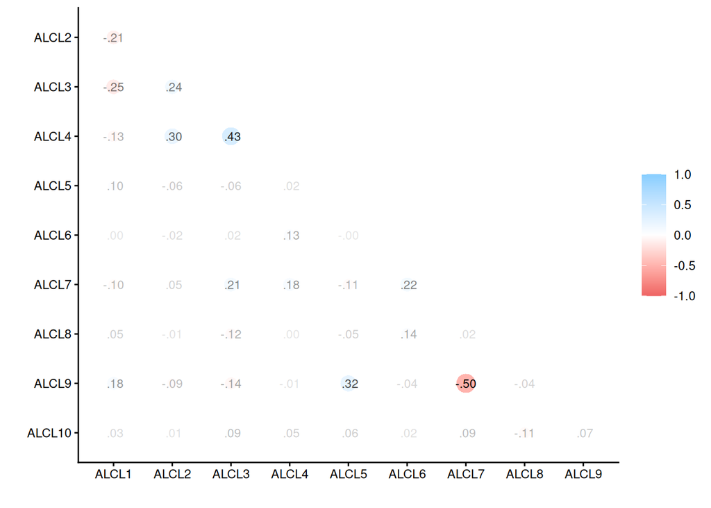

Figure 12: Correlation matrix of the ten local preference items for respondents who voted for F. SF - Socialistisk Folkeparti in the local election.

```r
data |>
  filter(VOTE_LOC_PRTY == "F. SF - Socialistisk Folkeparti") |>
  select(paste0("ALCL", 1:10)) |>
  correlate() |>
  shave() |>
  rplot(print_cor = TRUE)
```

```
Correlation computed with
• Method: 'pearson'
• Missing treated using: 'pairwise.complete.obs'
```

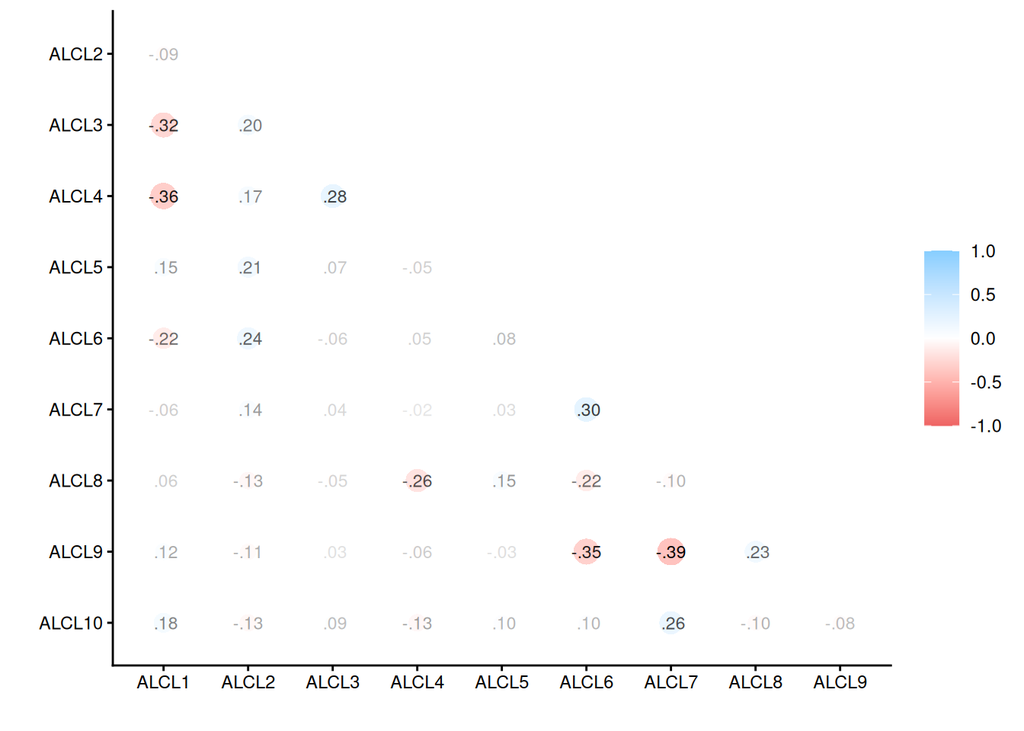

Figure 13: Correlation matrix of the ten local preference items for respondents who voted for Ø. Enhedslisten – De Rød-Grønne in the local election.

```r
data |>
  filter(VOTE_LOC_PRTY == "Ø. Enhedslisten – De Rød-Grønne") |>
  select(paste0("ALCL", 1:10)) |>
  correlate() |>
  shave() |>
  rplot(print_cor = TRUE)
```

```
Correlation computed with
• Method: 'pearson'
• Missing treated using: 'pairwise.complete.obs'
```

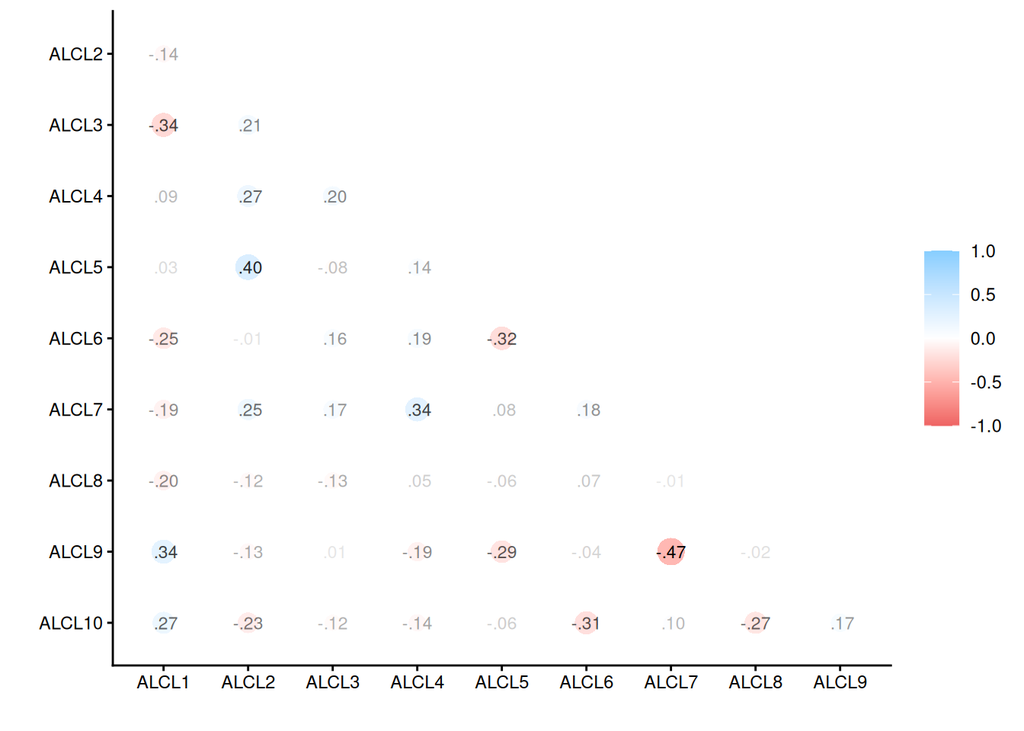

Figure 14: Correlation matrix of the ten local preference items for respondents who voted for B. Radikale Venstre in the local election.

```r
data |>
  filter(VOTE_LOC_PRTY == "B. Radikale Venstre") |>
  select(paste0("ALCL", 1:10)) |>
  correlate() |>
  shave() |>
  rplot(print_cor = TRUE)
```

```
Correlation computed with
• Method: 'pearson'
• Missing treated using: 'pairwise.complete.obs'
```

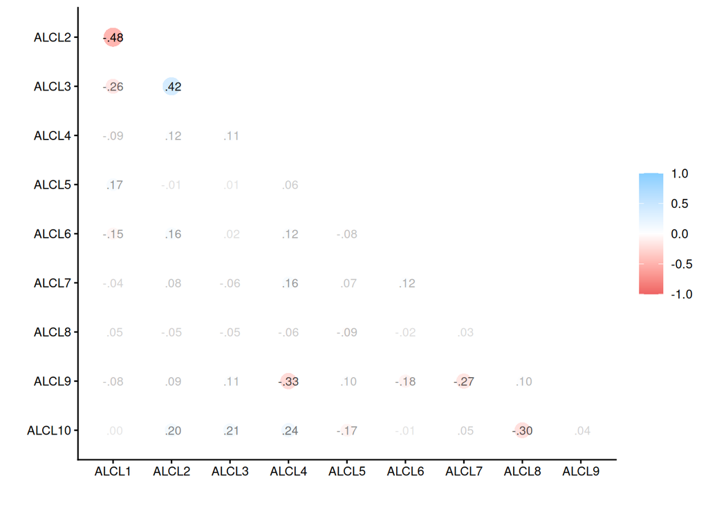

Figure 15: Correlation matrix of the ten local preference items for respondents who voted for C. Det Konservative Folkeparti in the local election.

```r
data |>
  filter(VOTE_LOC_PRTY == "C. Det Konservative Folkeparti") |>
  select(paste0("ALCL", 1:10)) |>
  correlate() |>
  shave() |>
  rplot(print_cor = TRUE)
```

```
Correlation computed with
• Method: 'pearson'
• Missing treated using: 'pairwise.complete.obs'
```

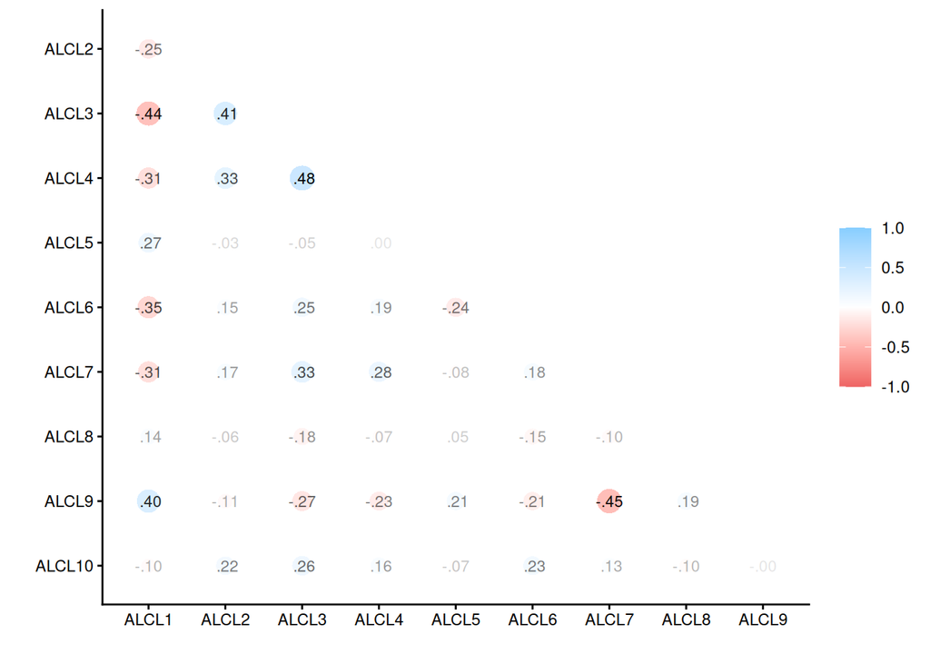

Figure 16: Correlation matrix of the ten local preference items for respondents younger than 30 years.

```r
data |>
  filter(AGE < 30) |>
  select(paste0("ALCL", 1:10)) |>
  correlate() |>
  shave() |>
  rplot(print_cor = TRUE)
```

```
Correlation computed with
• Method: 'pearson'
• Missing treated using: 'pairwise.complete.obs'
```

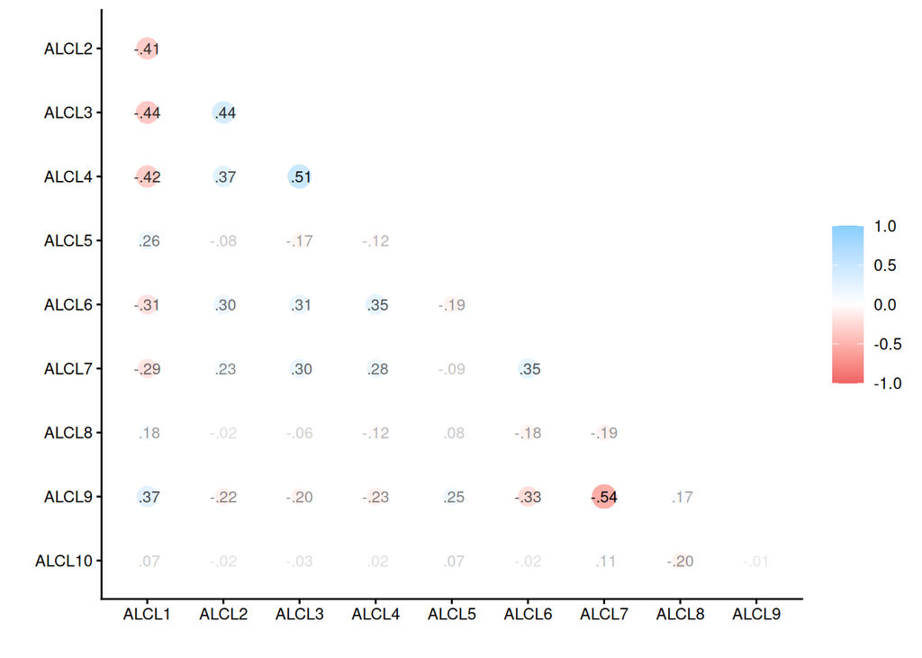

Figure 17: Correlation matrix of the ten local preference items for respondents older than 55 years.

```r
data |>
  filter(AGE > 55) |>
  select(paste0("ALCL", 1:10)) |>
  correlate() |>
  shave() |>
  rplot(print_cor = TRUE)
```

```
Correlation computed with
• Method: 'pearson'
• Missing treated using: 'pairwise.complete.obs'
```

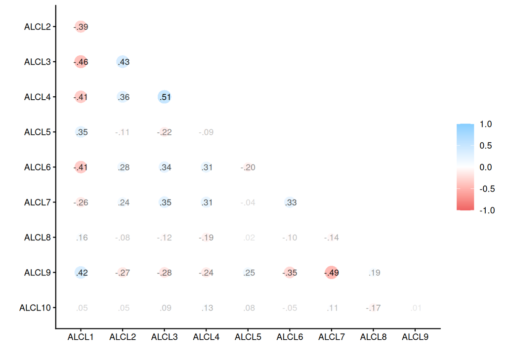

Figure 18: Correlation matrix of the ten local preference items for male respondents.

```r
data |>
  filter(GENDER == "Male") |>
  select(paste0("ALCL", 1:10)) |>
  correlate() |>
  shave() |>
  rplot(print_cor = TRUE)
```

```
Correlation computed with
• Method: 'pearson'
• Missing treated using: 'pairwise.complete.obs'
```

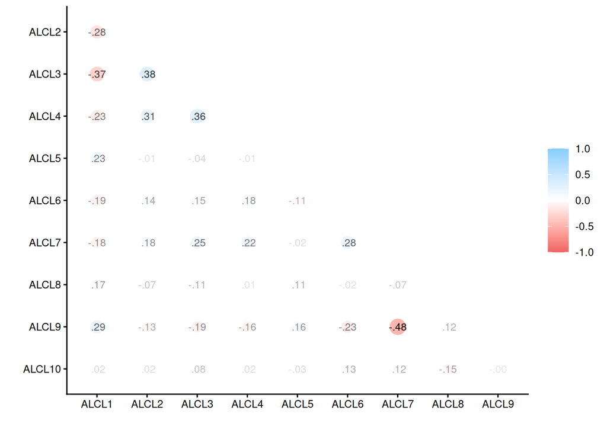

Figure 19: Correlation matrix of the ten local preference items for female respondents.

```r
data |>
  filter(GENDER == "Female") |>
  select(paste0("ALCL", 1:10)) |>
  correlate() |>
  shave() |>
  rplot(print_cor = TRUE)
```

## 3 Voting

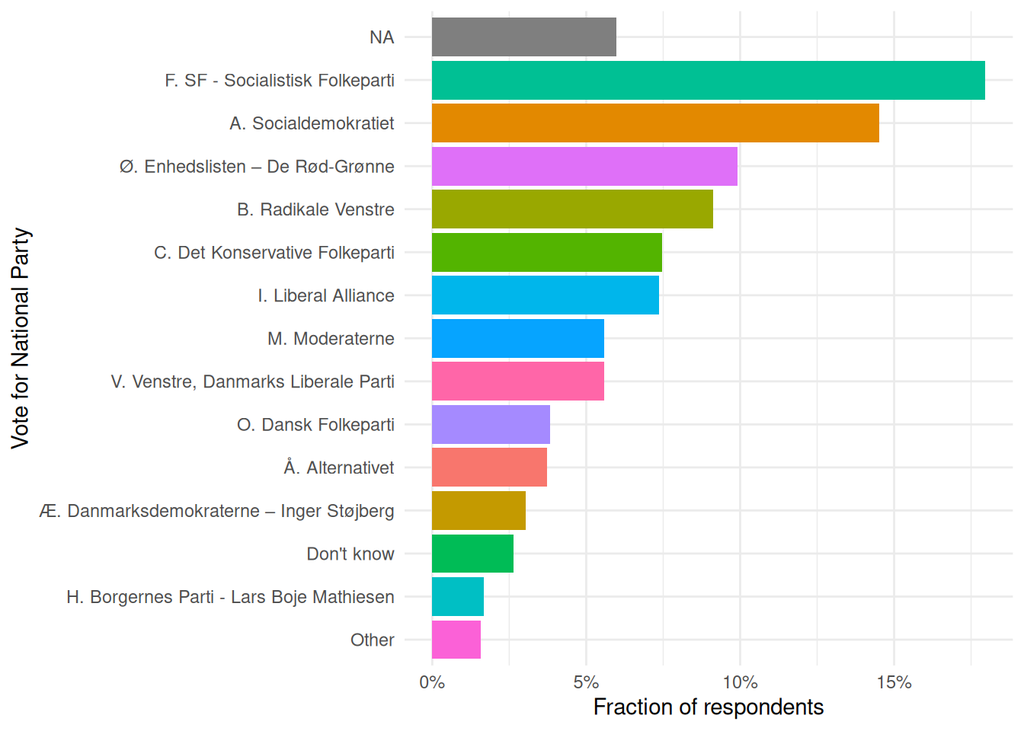

Figure 20: Vote for National Party

```r
data |>
  ggplot(aes(
    y = VOTE_NAT_PRTY |> fct_infreq() |> fct_rev(),
    fill = VOTE_NAT_PRTY
  )) +
  geom_bar(aes(x = after_stat(count / sum(count))), stat = "count") +
  labs(x = "Fraction of respondents", y = "Vote for National Party") +
  scale_x_continuous(labels = percent_format(accuracy = 1)) +
  guides(fill = "none") +
  theme_minimal()
```

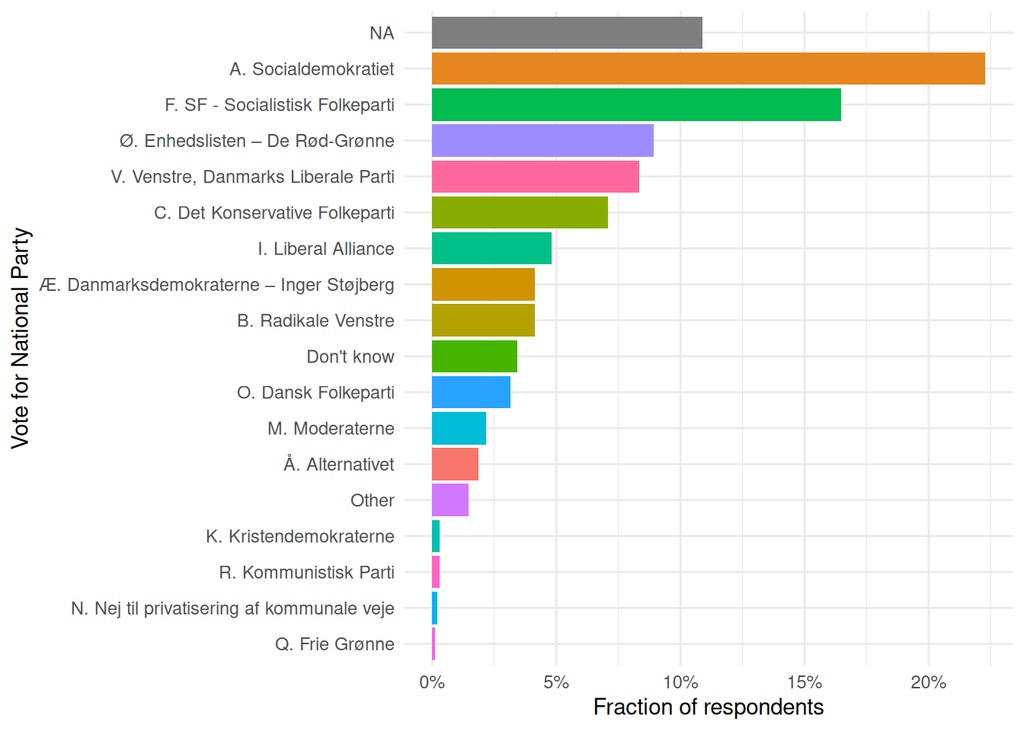

Figure 21: Vote for Local Party

```r
data |>
  ggplot(aes(
    y = VOTE_LOC_PRTY |> fct_infreq() |> fct_rev(),
    fill = VOTE_LOC_PRTY
  )) +
  geom_bar(aes(x = after_stat(count / sum(count))), stat = "count") +
  labs(x = "Fraction of respondents", y = "Vote for National Party") +
  scale_x_continuous(labels = percent_format(accuracy = 1)) +
  guides(fill = "none") +
  theme_minimal()
```

## 4 Voting System Satisfaction and Reform

SSBS1: *In Danish national elections, each voter casts one vote for a party or candidate; and seats in Parliament are allocated using proportional representation. Overall, how satisfied are you with this voting system?*

SSBS2: *I am confident that I understand how my vote is translated into the final election outcome under the current system.*

SQDR1: *In some electoral systems, voters can allocate more than one vote across candidates or parties, rather than casting only a single vote. To what extent would you support or oppose introducing such a system?*

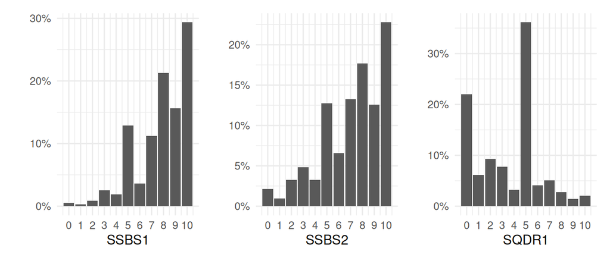

Figure 22: Voting system satisfaction, certainty, and reform support.

```r
vs1 <- data |>
  ggplot(aes(x = SSBS1)) +
  geom_bar(aes(y = after_stat(count / sum(count))), stat = "count") +
  scale_y_continuous(labels = percent_format(accuracy = 1)) +
  scale_x_continuous(breaks = 0:10) +
  labs(y = "") +
  theme_minimal()
vs2 <- data |>
  ggplot(aes(x = SSBS2)) +
  geom_bar(aes(y = after_stat(count / sum(count))), stat = "count") +
  scale_y_continuous(labels = percent_format(accuracy = 1)) +
  scale_x_continuous(breaks = 0:10) +
  labs(y = "") +
  theme_minimal()
vs3 <- data |>
  ggplot(aes(x = SQDR1)) +
  geom_bar(aes(y = after_stat(count / sum(count))), stat = "count") +
  scale_y_continuous(labels = percent_format(accuracy = 1)) +
  scale_x_continuous(breaks = 0:10) +
  labs(y = "") +
  theme_minimal()

vs1 + vs2 + vs3 + plot_layout(nrow = 1)
```

SRQV1: *Suppose everyone had 10 votes to allocate. In your opinion, how should voters be allowed to distribute them?*

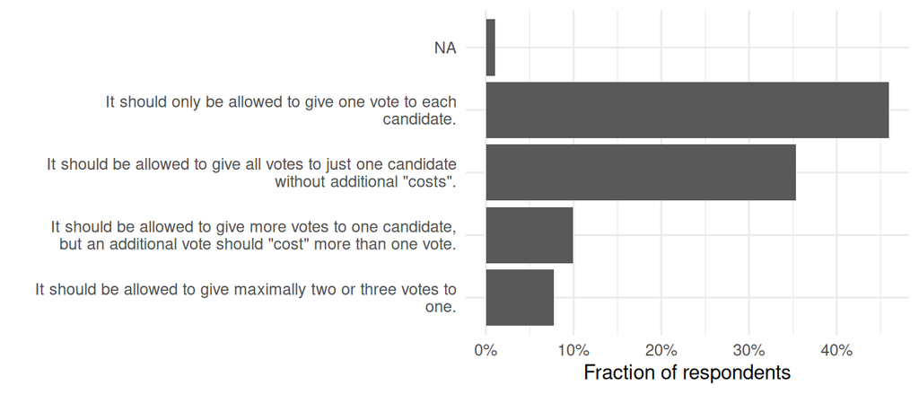

Figure 23: Preferred distribution of votes in a multi-vote electoral system.

```r
data |>
  ggplot(aes(y = SRQV1 |> fct_infreq() |> fct_rev())) +
  geom_bar(aes(x = after_stat(count / sum(count))), stat = "count") +
  scale_y_discrete(labels = function(x) stringr::str_wrap(x, width = 60)) +
  scale_x_continuous(labels = percent_format(accuracy = 1)) +
  labs(x = "Fraction of respondents", y = "") +
  theme_minimal()
```

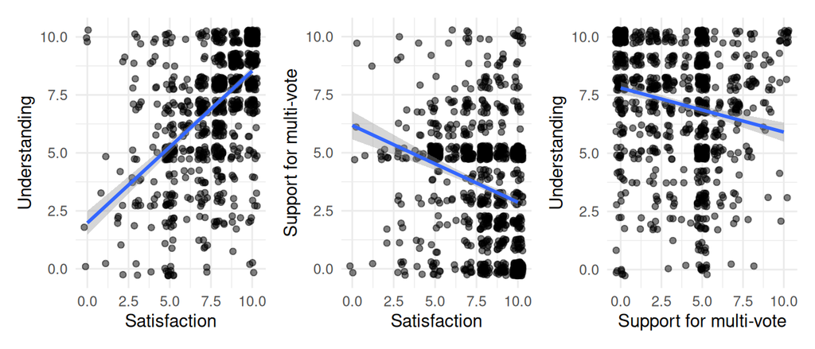

Figure 24: Satisfaction vs. Certainty vs. Reform Support

```r
sc1 <- data |>
  ggplot(aes(x = SSBS1, y = SSBS2)) +
  geom_jitter(alpha = 0.5, width = 0.3, height = 0.3) +
  geom_smooth(method = "lm", formula = 'y ~ x') +
  labs(
    x = "Satisfaction",
    y = "Understanding"
  ) +
  theme_minimal()

sc2 <- data |>
  ggplot(aes(x = SSBS1, y = SQDR1)) +
  geom_jitter(alpha = 0.5, width = 0.3, height = 0.3) +
  geom_smooth(method = "lm", formula = 'y ~ x') +
  labs(
    x = "Satisfaction",
    y = "Support for multi-vote"
  ) +
  theme_minimal()

sc3 <- data |>
  ggplot(aes(x = SQDR1, y = SSBS2)) +
  geom_jitter(alpha = 0.5, width = 0.3, height = 0.3) +
  geom_smooth(method = "lm", formula = 'y ~ x') +
  labs(
    y = "Understanding",
    x = "Support for multi-vote"
  ) +
  theme_minimal()

sc1 + sc2 + sc3 + plot_layout(nrow = 1)
```

## References

Gestefeld, Martin, Jan Lorenz, Nils Tobias Henschel, and Klaus Boehnke. 2022. “Decomposing Attitude Distributions to Characterize Attitude Polarization in Europe.” *SN Social Sciences* 2 (7): 110. https://doi.org/10.1007/s43545-022-00342-7.